# Expérimentations par assignation aléatoire

Atelier Statcap : Evaluation d’impact sur données spatiales

Florent Bédécarrats & Thomas Thivillon

January 1, 2025

## Le problème principal du modèle de Rubin

Le problème principal soulevé par le modèle de Rubin lors de l’évaluation des effets d’une intervention est l’impossibilité d’observer :

$$\mathbb{E}(Y_{0i} \mid T_i = 1)$$

### Problème du contrefactuel

- **Question clé** : Quel aurait été le **résultat observé** sur les unités traitées **en l’absence du traitement** ?
- **Enjeu** : Trouver un contrefactuel valide / pertinent.
- **Menaces** :
  - Éligibilité au programme
  - Auto-sélection ⟹ biais entre traités et non-traités
- **Une solution** : Les essais randomisés contrôlés (ERC)

## Pourquoi la randomisation ?

**Randomisation** : Le fait de participer au projet ou non est défini de **façon aléatoire** (exemple = à l’aide d’une loterie).

- Deux groupes sont aléatoirement choisis au sein d’une population “homogène” :
  - Un groupe bénéficie de l’intervention (vaccin, prêt, formation, statut d’aire protégée) = **groupe de traitement**.
  - L’autre groupe ne bénéficie pas de l’intervention = **groupe de contrôle**.
- L’assignation aléatoire permet d’obtenir deux groupes probablement très similaires (dispersion des observables et inobservables statistiquement identiques)… **si les groupes sont suffisamment importants !**

## Pourquoi la randomisation ?

Si on tire au sort un grand nombre d’individus, la distribution dans l’échantillon est très proche de celle de la population totale :

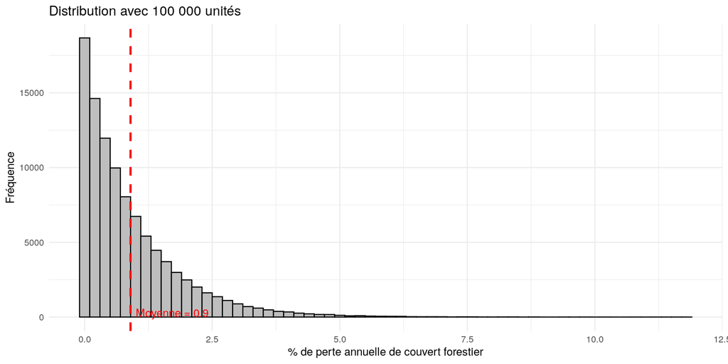

## Pourquoi la randomisation ?

Si maintenant on tire au sort un échantillon beaucoup plus petit, il y a de fortes chances pour que nos distributions diffèrent fortement de celle de la population totale.

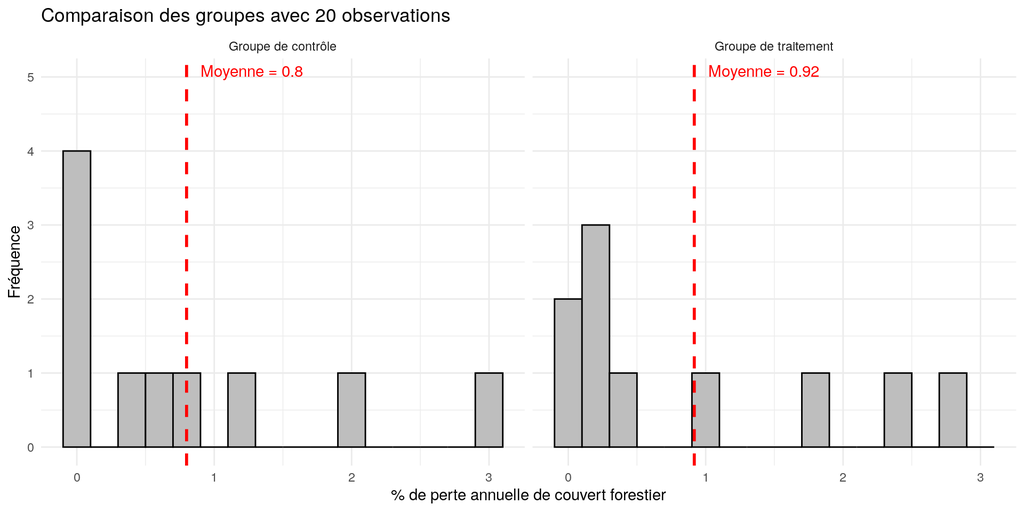

## Pourquoi la randomisation ?

Plus la taille de l’échantillon grandit, plus la distribution ressemble à celle de la population totale et la moyenne ou la médiane des groupes de traitement et de contrôle se rapprochent (avec une dimension aléatoire toutefois).

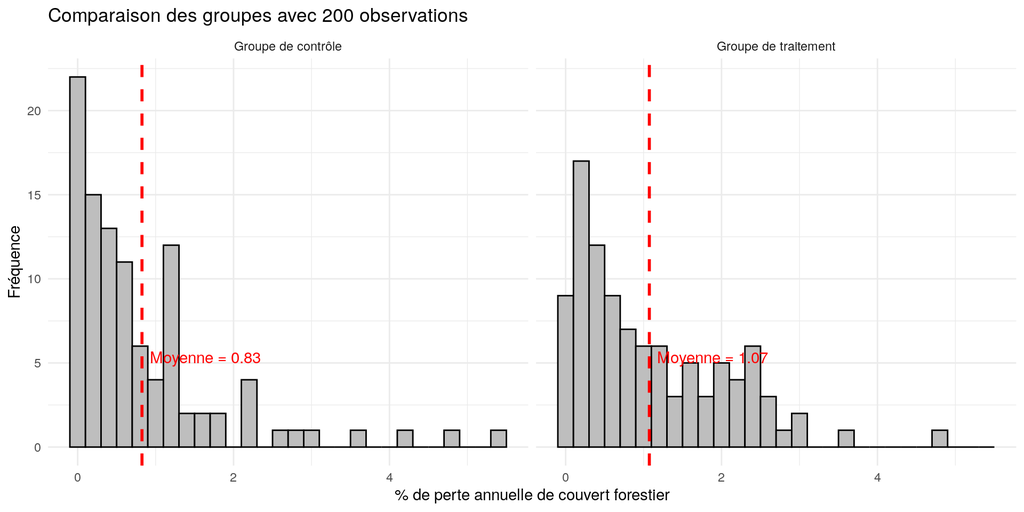

## Pourquoi la randomisation ?

A partir de 1000 unités, on commence à avoir une relative similitude.

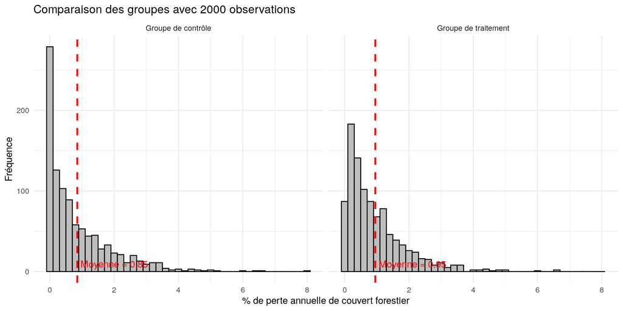

## Pourquoi la randomisation?

- En s’appuyant sur le tirage aléatoire de deux sous-échantillons de la population cible, nous devrions observer une distribution similaire des caractéristiques observables et inobservables :

  $$E(X \mid T = 1) = E(X \mid T = 0) = E(X)$$
- De même, en l’absence du programme, la distribution des variables de résultats devrait être identique (absence de biais de sélection).
- Ainsi, le groupe de contrôle devient un **contrefactuel pertinent**. L’hypothèse suivante devient beaucoup plus réaliste :

  $$E(Y_0 \mid T = 0) = E(Y_0 \mid T = 1) = E(Y_0)$$

## Pourquoi la randomisation?

- **Attention !** L’hypothèse faite sur la validité du contrefactuel n’est valable qu’en moyenne (impossible de dire que $X_i(1) = X_i(0)$ et que $Y_i(1) = Y_i(0)$).
- Nous pouvons uniquement essayer de mesurer l’**effet moyen** du programme qui est obtenu par :

  $$E(Y_i \mid T_i = 1) - E(Y_i \mid T_i = 0)$$

## Estimation de l’effet moyen du traitement

- **Différence de moyennes** :
  $$E(Y_{1i} \mid T_i = 1) - E(Y_{0i} \mid T_i = 0) \longrightarrow \overline{Y}_1 - \overline{Y}_0$$
- **Régression linéaire** :
  $$Y_i = \alpha + \beta T_i + \epsilon_i$$
  avec :
  - $\beta$ : l’effet moyen du traitement
  - $\alpha$ : la moyenne de $Y_i$ pour les non-traités
  - $\epsilon$ : le terme d’erreur

## Comment randomiser?

Quel est le processus à suivre pour “randomiser” un projet/programme/intervention? Plusieurs étapes :

1. **Identification des unités éligibles** au programme (individus, ménages, écoles, villages, aires géographiques) : les unités pour lesquelles nous voulons connaître l’impact du programme.
2. **Sélection de l’échantillon soumis à l’évaluation** (extraction de la population d’intérêt).
3. **Assignation aléatoire** du traitement (quel groupe bénéficie de l’intervention?).

## Processus d’échantillonage aléatoire

```
flowchart TD
    A["Population<br/>éligible"] --> AB(Faisabilité)
    AB --> B["Échantillon<br/>étudié"]
    B --> C("Assignation<br/>aléatoire")
    C --> D["Groupe de<br/>traitement"]
    C --> E["Groupe de<br/>contrôle"]

    style A fill:#d3d3d3,color:#000000
    style B fill:#d3d3d3,color:#000000
    style D fill:#3cb371,color:#000000
    style E fill:#ff6347,color:#000000
```

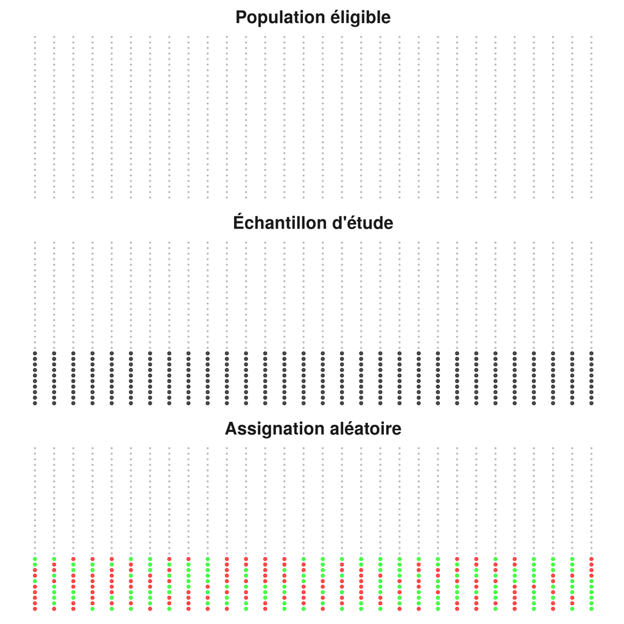

## A quel niveau effectuer le tirage ?

Dans les faits, les unités sont souvent imbriquées :

- Niveau 1 : ex. région, académie…
- Niveau 2 : ex. aire protégée, classe…
- Niveau individuel : parcelle, élève…

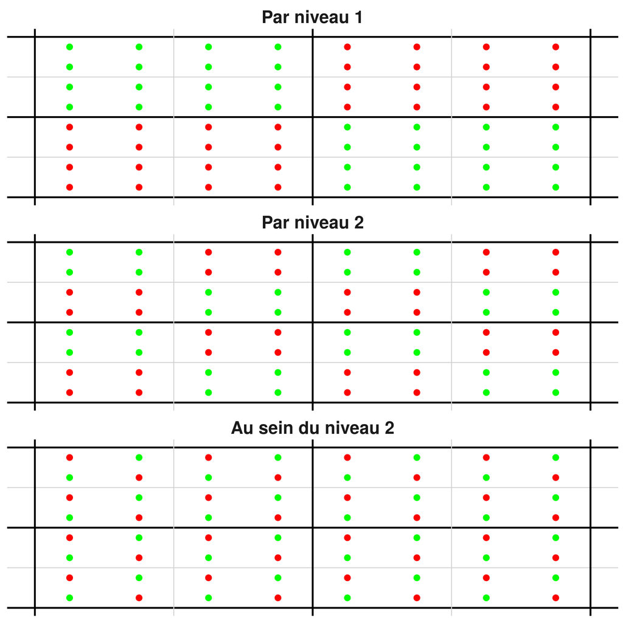

## A quel niveau faut-il effectuer le tirage?

Le niveau du tirage dépend de celui de l’intervention : le niveau de randomisation ne peut être inférieur au niveau auquel est assigné le programme.

La randomisation n’est pas la panacée : sa pertinence dépend du type d’intervention ⟶ **arbitrages** :

- Un niveau trop agrégé de l’assignation (régions, pays, provinces) diminue la puissance statistique et augmente le risque de facteurs confondants.
- Assigner une intervention à un niveau très désagrégé (individu, ménage) augmente les risques de contamination du groupe de contrôle.

## Validité interne

**Validité interne** : La différence observée sur les variables de résultats entre traités et non-traités est attribuable à l’intervention et à l’intervention seulement.

- **Validité interne** : assignation aléatoire du traitement
  - Le groupe de contrôle est similaire au groupe de traitement (en moyenne) avant l’intervention.
  - Une fois l’intervention commencée, les deux groupes sont exposés au même environnement et aux mêmes évolutions temporelles.
  - Groupe de contrôle : bonne représentation de ce qu’il serait arrivé aux “traités” en l’absence de traitement.
  - La différence de résultats entre traités et non-traités après l’intervention est donc due à cette dernière.

## Difficultés avec les ERC

1. Validité externe

**Validité externe** : Les résultats de l’évaluation sont généralisables à l’ensemble des unités éligibles (dans le temps, dans d’autres contextes).

- La validité externe des ERC est faible. En effet, ils conduisent à l’obtention de résultats…
  - Qui sont spécifiques à un pays, une population spécifique (celle de l’étude), à un moment donné.
  - Qui ne peuvent être extrapolés à d’autres endroits du monde et sur d’autres populations.
  - Qui nous permettent néanmoins de comprendre les effets d’une intervention dans un contexte spécifique.

## Difficultés avec les ERC

1. Validité externe
2. Enjeux éthiques

**Enjeux éthiques** : les gens ne sont pas des hamsters

- La sélection aléatoire conduit à refuser le traitement à un ensemble de personnes à l’instant T.
- Questionnable lorsque les interventions évaluées par ERC portent sur les besoins humains.
- Les ERC comme étalon-or de l’évaluation des politiques de développement? ⟶ Décrédibilisation des autres approches évaluatives.

## Difficultés avec les ERC

1. Validité externe
2. Enjeux éthiques
3. Enjeux statistiques

**Enjeux statistiques** : être sûr de pouvoir détecter un effet

- Les enquêtes sur un grand nombre d’individus, et la mise en place de l’attribution aléatoire de l’intervention sont coûteuses.
- Arbitrage entre précision de l’évaluation et moyens financiers.
- Tout ne peut pas être testé avec les ERC.

## Difficultés avec les ERC

1. Validité externe
2. Enjeux éthiques
3. Enjeux statistiques
4. Contamination et externalités

**Contamination et externalités** : menaces sur la validité interne

- Certains non-traités peuvent en réalité bénéficier de manière indirecte de l’intervention (ex : Kremer & Miguel, 2004).
- L’intervention peut avoir des conséquences sur des facteurs environnementaux qui vont impacter les variables de résultats (changement de prix).
- Ajustement des comportements (Hawthorne effect, John Henry effect, Découragement).

# Discussion et mise en pratique

# Rappels sur les régressions

## Principe de la régression linéaire simple

- L’objectif de la régression linéaire simple est de modéliser la relation entre une variable dépendante $y$ et une variable indépendante $x$.
- On fait l’hypothèse que cette relation est linéaire.
- On recherche la ligne qui va minimiser la distance verticale entre chacun des points de données $(x_i, y_i)$ et elle_même.

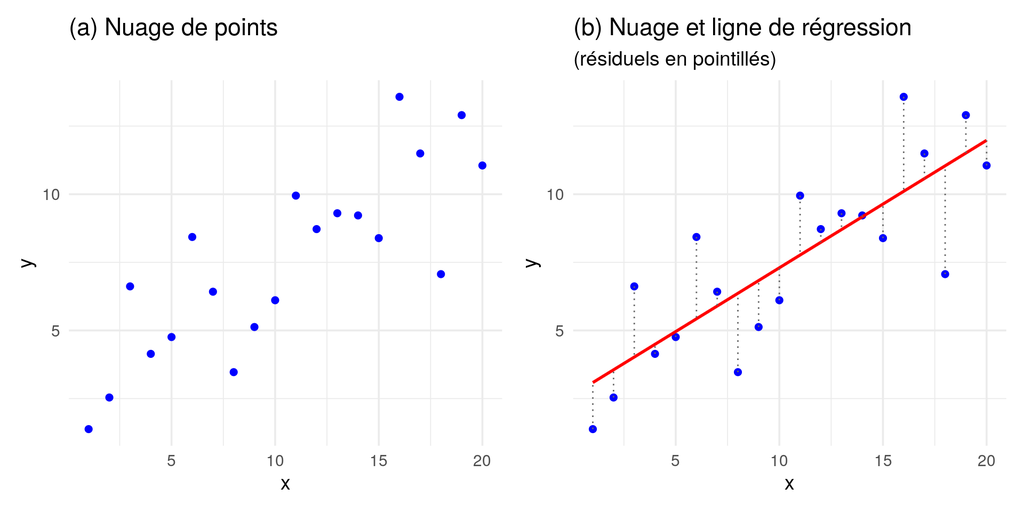

Figure 1

## Estimation de la régression linéaire

- On cherche à estimer les coefficients $a$ et $b$ de la droite :

$$\hat{y} = a + bx$$
- Cette droite est notre estimateur de la relation entre $x$ et $y$ dans la population :

$$y = a + bx + u$$
- Pour un individu $i$, on a :

$$y_i = a + bx_i + u_i$$

## Estimation de la régression linéaire

- On peut montrer que le coefficient $b$ est donné par la formule :

$$\hat{b} = \frac{\sum_{i=1}^n (x_i - \bar{x})(y_i - \bar{y})}{\sum_{i=1}^n (x_i - \bar{x})^2}$$
qui peut aussi s’écrire :

$$\hat{b} = \frac{Cov(x,y)}{Var(x)}$$

## Estimation de la régression linéaire

- On peut ensuite utiliser le fait que la droite de régression passe nécessairement par le point moyen $(\bar{x}, \bar{y}))$ pour en déduire la valeur de $a$ :

$$\hat{a} = \bar{y} - \hat{b}\bar{x}$$

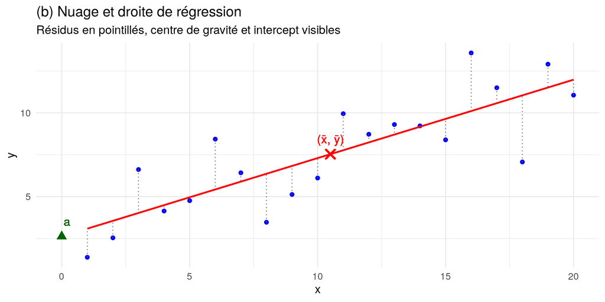

Figure 2

## Exemple d’application

On modélise la relation entre la distance à la ville la plus proche et le taux de déforestation annuel de 4 aires protégées.

Voici la structure des données :

Données des 4 aires protégées

| nom | distance_ville | deforestation |
| --- | --- | --- |
| Aire 1 | 20 | 3.5 |
| Aire 2 | 50 | 2.8 |
| Aire 3 | 80 | 1.9 |
| Aire 4 | 100 | 1.2 |

## Calcul des moyennes

Données des 4 aires protégées

| nom | distance_ville | deforestation |
| --- | --- | --- |
| Aire 1 | 20 | 3.5 |
| Aire 2 | 50 | 2.8 |
| Aire 3 | 80 | 1.9 |
| Aire 4 | 100 | 1.2 |

$$\bar{x} = \frac{20 + 50 + 80 + 100}{4} = \frac{250}{4} = 62.5$$

$$bar{y} = \frac{3.5 + 2.8 + 1.9 + 1.2}{4} = \frac{9.4}{4} = 2.35$$

## Calculs intermédiaires

| $x_i$ | $y_i$ | $x_i - \bar{x}$ | $y_i - \bar{y}$ | $(x_i - \bar{x})(y_i - \bar{y})$ | $(x_i - \bar{x})^2$ |
| --- | --- | --- | --- | --- | --- |
| 20 | 3.5 | -42.5 | 1.15 | -48.875 | 1806.25 |
| 50 | 2.8 | -12.5 | 0.45 | -5.625 | 156.25 |
| 80 | 1.9 | 17.5 | -0.45 | -7.875 | 306.25 |
| 100 | 1.2 | 37.5 | -1.15 | -43.125 | 1406.25 |

$$\
\sum (x_i - \bar{x})(y_i - \bar{y}) = -105.5 \quad ; \quad \sum (x_i - \bar{x})^2 = 3675$$

## Calcul des coefficients

$$\
b = \frac{-105.5}{3675} ≈ -0.0287$$

$$\
a = \bar{y} - b \cdot \bar{x} = 2.35 - (-0.0287 \cdot 62.5) = 2.35 + 1.79375 ≈ 4.144$$

## Équation de la droite de régression

$$\hat{y} = 4.14 - 0.029 \cdot x$$

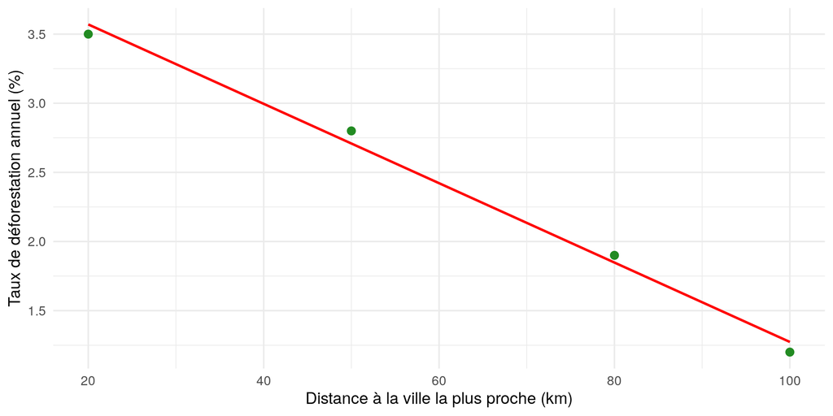